# Project 02

Max Wagner

october 8th, 2015

## Motocross des Nations

The first set of the 3 I am going to look at is some web scraped data from the wikipedia page on Motocross des Nations. The link to the original page can be found [here](https://en.wikipedia.org/wiki/Motocross_des_Nations). It doesn’t use much/any tidyr/dplyr, but it does use webscraping with rvest, piping, and quite a bit of data tranformation via other methods. Most of the tidying is taken care of by rvest, and the way the table information is read in.

The idea behind Motocross des Nations is that every country is able to send 3 of their best riders to one race that varies in location each year. The table I’ll be reading in has two main components, the first is finishing position, the other important aspect is whether the team participated or not. I want to check if participation has correlation with finishing position.

The first piece is loading in the libraries I need, and a function that does some string replacing in numbers.

```r
library(rvest)
library(stringr)
library(dplyr)
library(ggplot2)

stripSuffix <- function(string) {
  string <- str_replace(string, "st", "")
  string <- str_replace(string, "nd", "")
  string <- str_replace(string, "rd", "")
  string <- str_replace(string, "th", "")
  return(string)
}
```

The next section scrapes the table of des Nations’ stats from a wikipedia page using a xpath.

```r
url <- "https://en.wikipedia.org/wiki/Motocross_des_Nations"
xpath <- '//*[@id="mw-content-text"]/table[3]'
mdn <- url %>%
  read_html() %>%
  html_nodes(xpath = xpath) %>%
  html_table(header = TRUE)
mdn <- mdn[[1]]
```

I then remove the last column, as it is useless, then pull out the names of the countries into a separate vector. I then remove the last row from both of them.

```r
mdn$Years <- NULL
country <- mdn[1:54,1]
mdn <- mdn[1:54,2:17]
```

I then strip the suffixes from the numbers frame with the function I loaded in earlier.

```r
for (i in 1:16) {
  mdn[,i] <- stripSuffix(mdn[,i])
}
```

Add a column the tracks how many years teams participated in.

```r
for (i in 1:54) {
  if (i == 1) {
    mdn$participated[i] <- sum(mdn[i,] != "")
  } else {
    mdn$participated[i] <- sum(mdn[i,] != "") - 1
  }
}
```

Add 0’s to blank spots, then convert the table to numerics.

```r
mdn[mdn == ""] <- 0
for (i in 1:16) {
  mdn[,i] <- as.numeric(mdn[,i])
}
```

Add columns for sum of postions during the years, and the team’s average finishing position. Then, remove the sum column.

```r
for (i in 1:54) {
  mdn$sum[i] <- rowSums(mdn[i,1:16])
}
mdn <- mutate(mdn, avg = sum / participated)
mdn$sum <- NULL
```

Bind the country vector and finishing data back together. The finished product is a table where each row represents; a country, their finishing position from the year 2000-2015, how many years they participated in, and their average finishing position. The added 0’s represent years the team did not participate, as this method is typically used in motocross.

```r
mdn <- cbind(country, mdn)
```

I can then manipulate the whole table with dplyr. Then, view the head of the new table.

```r
mdn <- arrange(mdn, avg)
head(mdn)
```

```
##         country 2000 2001 2002 2003 2004 2005 2006 2007 2008 2009 2010
## 1           USA    1    0    0    2    0    1    1    1    1    1    1
## 2       Belgium    3    2    2    1    1    3    2    3    3    3    2
## 3        France   18    1    6    9    3    2    5    2    2    2    7
## 4 Great Britain    4    4    0    6    9    5    6    5    4    5    4
## 5         Italy    2   17    1   17   15   13    4    4    5    6    5
## 6       Germany   10    5   16   19   11   14   13    9   10    4    3
##   2011 2012 2013 2014 2015 participated      avg
## 1    1    3    2    3    2           13 1.538462
## 2    5    2    1    2    3           16 2.375000
## 3    2    6    5    1    1           16 4.500000
## 4    4    8    6    4   18           15 6.133333
## 5   16    5    3    6   14           16 8.312500
## 6    7    1    7    5    9           16 8.937500
```

The next step is looking at the participation vs average finishing position.

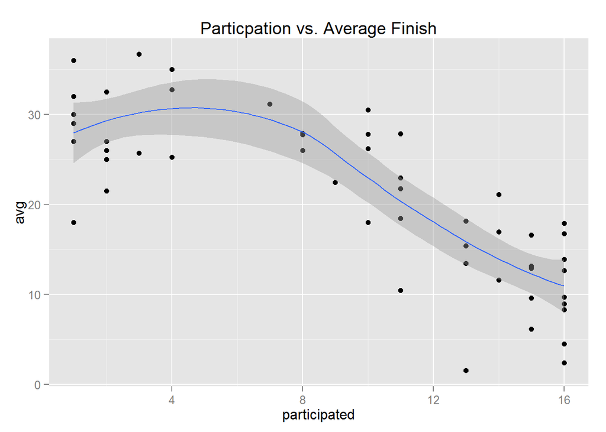

```r
qplot(data = mdn, participated, avg) + ggtitle("Particpation vs. Average Finish") + stat_smooth()
```

There is definitely a correlation between participation and average finishing position, it is -0.7918109 in this case. As I expected, as participation by a team increases, their average finishing position decreases.